# Example test

Author

Maciej Beręsewicz

# 1 Question 1

Consider the following variable: **Number of ice creams eaten by kindergarten children in a given week in Poznań** presented below:

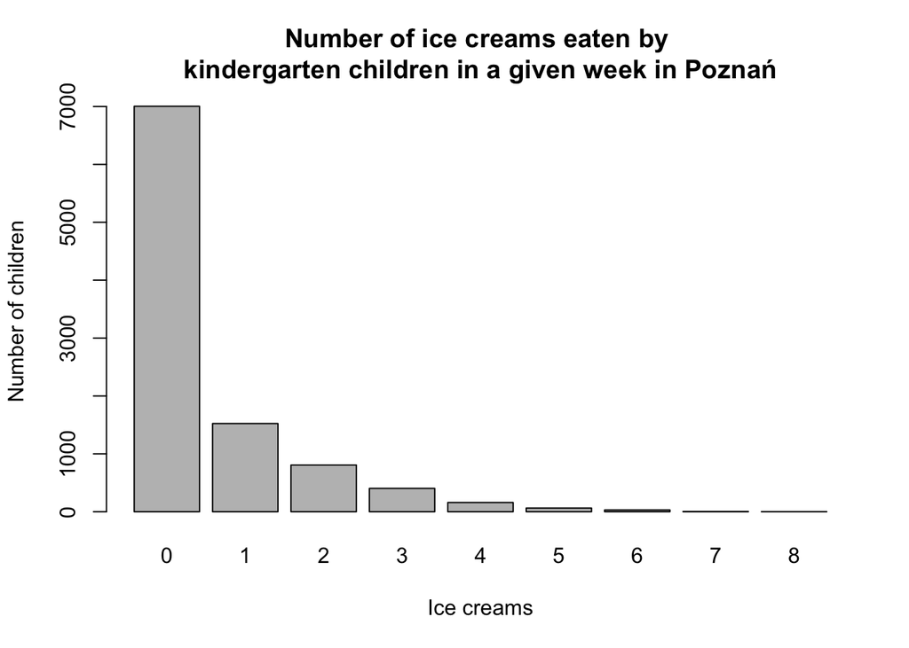

We observe a lot of zeros, so we should consider models that fit such data: zero-inflated or hurdle. Which model should we use and why? Justify your answer.

# 2 Question 2

Given the following outputs please answer the following questions:

1. What models were fitted?
2. Which model is better and why?
3. Provide interpretation of parameter `school` for the count model and `school` for the zero-inflated model.

Model 1 (ZIP)

```r
Call:
zeroinfl(formula = daysabs ~ gender + school + mathnce + langnce, data = df, dist = "poisson")

Pearson residuals:
   Min     1Q Median     3Q    Max
-2.483 -1.229 -0.678  0.591 12.991

Count model coefficients (poisson with log link):
             Estimate Std. Error z value Pr(>|z|)
(Intercept)  3.106464   0.087154  35.644  < 2e-16 ***
gendermale  -0.275673   0.048705  -5.660 1.51e-08 ***
school      -0.671446   0.056862 -11.808  < 2e-16 ***
mathnce      0.002475   0.001869   1.324   0.1855
langnce     -0.004396   0.001982  -2.217   0.0266 *

Zero-inflation model coefficients (binomial with logit link):
            Estimate Std. Error z value Pr(>|z|)
(Intercept) -4.54127    0.73604  -6.170 6.83e-10 ***
gendermale   0.94806    0.31765   2.985  0.00284 **
school       0.81546    0.33659   2.423  0.01541 *
mathnce      0.01394    0.01176   1.185  0.23599
langnce      0.01128    0.01180   0.956  0.33906
---
Signif. codes:  0 '***' 0.001 '**' 0.01 '*' 0.05 '.' 0.1 ' ' 1

Number of iterations in BFGS optimization: 13
Log-likelihood: -1269 on 10 Df
```

Model 2 (ZINB)

```r
Call:
zeroinfl(formula = daysabs ~ gender + school + mathnce + langnce, data = df, dist = "negbin")

Pearson residuals:
    Min      1Q  Median      3Q     Max
-0.9549 -0.7045 -0.4003  0.2829  8.1607

Count model coefficients (negbin with log link):
             Estimate Std. Error z value Pr(>|z|)
(Intercept)  3.289159   0.255687  12.864  < 2e-16 ***
gendermale  -0.275842   0.138580  -1.990   0.0465 *
school      -0.771523   0.144921  -5.324 1.02e-07 ***
mathnce      0.004195   0.004903   0.856   0.3922
langnce     -0.009956   0.005501  -1.810   0.0703 .
Log(theta)   0.003446   0.125194   0.028   0.9780

Zero-inflation model coefficients (binomial with logit link):
            Estimate Std. Error z value Pr(>|z|)
(Intercept) -9.31443   15.61260  -0.597    0.551
gendermale   4.62124   15.92795   0.290    0.772
school       0.32701    0.95434   0.343    0.732
mathnce      0.05037    0.03578   1.408    0.159
langnce     -0.01103    0.03939  -0.280    0.779
---
Signif. codes:  0 '***' 0.001 '**' 0.01 '*' 0.05 '.' 0.1 ' ' 1

Theta = 1.0035
Number of iterations in BFGS optimization: 29
Log-likelihood: -864.3 on 11 Df
```

Model comparison

```r
> BIC(m1, m2)
   df      BIC
Model1 10 2595.501
Model2 11 1791.975
```

# 3 Question 3

We fitted negative binomial and zero-inflated negative binomial regression. Answer the questions based on the outputs:

1. Do we observe zero-inflation? If yes, why if not, why?
2. Based on this model can we say that males and females differ in terms of Y variable (`daysabs` days of absenteeism)?

Model 1 (NB)

```r
Call:
MASS::glm.nb(formula = daysabs ~ gender + school + mathnce +
    langnce, data = df, init.theta = 0.8687425507, link = log)

Coefficients:
             Estimate Std. Error z value Pr(>|z|)
(Intercept)  3.371968   0.258228  13.058  < 2e-16 ***
gendermale  -0.395827   0.134038  -2.953  0.00315 **
school      -0.769076   0.144925  -5.307 1.12e-07 ***
mathnce      0.002034   0.005125   0.397  0.69146
langnce     -0.009568   0.005273  -1.815  0.06959 .
---
Signif. codes:  0 ‘***’ 0.001 ‘**’ 0.01 ‘*’ 0.05 ‘.’ 0.1 ‘ ’ 1

(Dispersion parameter for Negative Binomial(0.8687) family taken to be 1)

    Null deviance: 409.95  on 315  degrees of freedom
Residual deviance: 357.39  on 311  degrees of freedom
AIC: 1746.3

Number of Fisher Scoring iterations: 1


              Theta:  0.8687
          Std. Err.:  0.0860

 2 x log-likelihood:  -1734.3020
```

Model 2 (ZINB)

```r
Call:
zeroinfl(formula = daysabs ~ gender + school + mathnce + langnce,
    data = df, dist = "negbin")

Pearson residuals:
    Min      1Q  Median      3Q     Max
-0.9549 -0.7045 -0.4003  0.2829  8.1607

Count model coefficients (negbin with log link):
             Estimate Std. Error z value Pr(>|z|)
(Intercept)  3.289159   0.255687  12.864  < 2e-16 ***
gendermale  -0.275842   0.138580  -1.990   0.0465 *
school      -0.771523   0.144921  -5.324 1.02e-07 ***
mathnce      0.004195   0.004903   0.856   0.3922
langnce     -0.009956   0.005501  -1.810   0.0703 .
Log(theta)   0.003446   0.125194   0.028   0.9780

Zero-inflation model coefficients (binomial with logit link):
            Estimate Std. Error z value Pr(>|z|)
(Intercept) -9.31443   15.61260  -0.597    0.551
gendermale   4.62124   15.92795   0.290    0.772
school       0.32701    0.95434   0.343    0.732
mathnce      0.05037    0.03578   1.408    0.159
langnce     -0.01103    0.03939  -0.280    0.779
---
Signif. codes:  0 '***' 0.001 '**' 0.01 '*' 0.05 '.' 0.1 ' ' 1

Theta = 1.0035
Number of iterations in BFGS optimization: 29
Log-likelihood: -864.3 on 11 Df
```

```r
> AIC(m3a, m3b)
    df      AIC
Model1  6 1746.302
Model2 11 1750.661

> BIC(m3a, m3b)
    df      BIC
Model1  6 1768.837
Model2 11 1791.975
```

# 4 Question 4

Specify which of these statements are true or false.

- Simpson’s Paradox suggests that a trend appears in different groups of data but disappears or reverses when these groups are combined.
- Simpson’s Paradox can be resolved by aggregating the data further.
- Simpson’s Paradox is an indication of a flaw in the data collection process.

# 5 Question 5

Specify which of these statements are true or false.

- Poisson models are preferred over Negative Binomial models when overdispersion is present in the data.
- Both Poisson and Negative Binomial distributions have the property that the mean is equal to the variance.
- Negative binomial distribution is a generalization of the Poisson distribution.